# Apêndice 2

Modelos populacionais matriciais aplicados à ecologia: Uma introdução à teoria e a prática - Versão preliminar

Author

Affiliation

[Gabriel S. Santos](https://ecosantos.netlify.app/)

Universidade do Estado do Rio de Janeiro

Published

July 15, 2026

O que você está vendo aqui é a versão preliminar do artigo “Modelos populacionais matriciais aplicados à ecologia: Uma introdução à teoria e a prática”. Clique em [Artigo](https://github.com/Ecosantos/MPM_Gentil/blob/main/Manuscrito.pdf) ou [Apêndice 1](https://github.com/Ecosantos/MPM_Gentil/blob/main/Ap%C3%AAndice%201.pdf) para acessar cada um dos respectivos documentos ou vá no meu repositório do Github [aqui](https://github.com/Ecosantos/MPM_Gentil)

### Configurações iniciais

Vamos começar limpando todos os dados que porventura estejam no R. Se algo muito ruim estiver acontencendo no seu R você pode sempre voltar nessa função para limpar seja lá qual erro você tiver cometido. O problema aqui é que esse comando vai limpar tudo que você fez até o momento. Seja prudente!

```r
rm(list=ls())
```

#### Instalar os pacotes necessáros

```r
install.packages("diagram")
install.packages("popbio")
install.packages("cowplot")
install.packages("tidyverse")
install.packages("ggrepel")
install.packages("popdemo")
install.packages("Hmisc")
```

```r
library(diagram)
library(popbio)
library(cowplot)
library(tidyverse)
library(ggrepel)
library(popdemo)
library(Hmisc)
```

#### Instalando os bancos de dados COMADRE e COMPADRE

clique [aqui](https://compadre-db.org/Data/Comadre#) para ir para o site do COMPADRE e COMADRE

```r
#É mais fácil se você escolher a pasta onde o arquivo está usando a função setwd
setwd(choose.dir())

#Depois basta carregar o arquivo
load( "COMADRE_v.4.26.4.0.RData" )

#OU use load(file.choose()) caso você tenha algum problema para encontrar o arquivo no seu computador
```

### MPM

#### Escolhendo uma matrix

```r
comadre$metadata%>%
filter(SpeciesAccepted == "Lontra canadensis")%>%
  select("SpeciesAccepted","Genus","Authors","Journal","DOI_ISBN")
```

| SpeciesAccepted | Genus | Authors | Journal | DOI_ISBN |
| --- | --- | --- | --- | --- |
| Lontra canadensis | Lontra | Gorman; McMillan; Erb; Deperno; Martin | Am Midl Nat | 10.1674/0003-0031(2008)159[98:SACMOA]2.0.CO;2 |

A matrix que temos interesse está na linha 1165 dos metadados do COMADRE. Então é essa a identidade da matriz que temos interesse. Vamos armazenar a identidade dessa matriz em um vetor:

```r
ID<-1165
```

Agora que sabemos a identidade dessa matriz podemos chamá-la a qualquer momento. Repare que na verdade temos quatro matrizes diferente = **matA**,**matF**,**matU** e **matC**.

```r
comadre$mat[ID]
```

```
[[1]]
[[1]]$matA
      A1   A2   A3
[1,] 0.0 0.00 2.81
[2,] 0.5 0.00 0.00
[3,] 0.0 0.45 0.45

[[1]]$matU
      U1   U2   U3
[1,] 0.0 0.00 0.00
[2,] 0.5 0.00 0.00
[3,] 0.0 0.45 0.45

[[1]]$matF
     F1 F2   F3
[1,]  0  0 2.81
[2,]  0  0 0.00
[3,]  0  0 0.00

[[1]]$matC
     C1 C2 C3
[1,]  0  0  0
[2,]  0  0  0
[3,]  0  0  0

[[1]]$MatrixID
[1] 248967
```

A Matriz A, que é a matriz de interesse aqui, na verdade é o resultado das taxas vitais em cada classe etária (sobrevivência e fecundidade) e que podem ser representadas cada uma como uma matriz separada.É exatamente isso que temos nos bancos de dados COMADRE e COMPADRE. Lá as matrizes são diferenciadas em matriz de fecundidade (matF), matriz de sobrevivência (matU) e matriz de de clonalidade (matC).

$$A = U + F + C$$
Vamos salvar nossa matriz A apenas.

```r
A<-comadre$mat[[ID]]$matA

#E vamos também adicionar o nome de cada estágio do nosso MPM
name <- c("1 ano","2 Anos",">2 Anos")
rownames(A)<-colnames(A)<-name

A
```

```
        1 ano 2 Anos >2 Anos
1 ano     0.0   0.00    2.81
2 Anos    0.5   0.00    0.00
>2 Anos   0.0   0.45    0.45
```

```r
#Tenha em mente que aqui estamos adaptando o MPM existente em Gorman et al. 2008.
#Apesar disso os nomes originais de cada classe etária pode ser adquirodo através do seguinte comando:
#colnames(A)<-do.call(rbind,strsplit(comadre$matrixClass[[ID]]$MatrixClassAuthor, "\\("))[,1]
```

#### Representação gráfica do nosso MPM

$$\begin{array}{cc} &
\begin{array}{ccc} 1 ano & 2 anos & >2 anos
\end{array}
\\
\begin{array}{ccc}
\\
A= \\
\end{array}
&
\left(
\begin{array}{ccc}
0 & f_{2}*p_{0} & f_{3}*p_{0}\\ S_{1,2} & 0 & 0\\ 0 & S_{2,3} & S_{3,3}
\end{array}
\right)
\end{array}$$

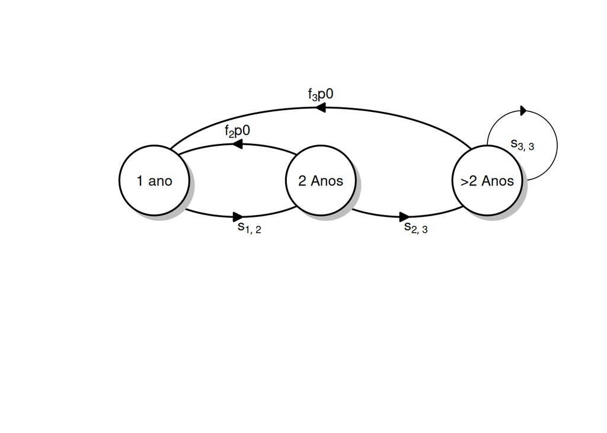

```r
Numgenerations <- dim(comadre$mat[[ID]]$matA)[1]
DiffMat <- matrix(data = 0, nrow = Numgenerations, ncol = Numgenerations)
AA <- as.data.frame(DiffMat)
#REP
 AA[[1,2]] <- "f[list(2)]*p0"
 AA[[1,3]] <- "f[list(3)]*p0"
 #
 AA[[2,1]] <- "s[list(1,2)]"
 AA[[3,2]] <- "s[list(2,3)]"
 AA[[3,3]] <- "s[list(3,3)]"
 #

diagram::plotmat(A = AA, pos=3, curve = 0.4, name = name, lwd = 2,
 arr.len = 0.2, arr.width = 0.2, my = .1,
 box.size = 0.07, arr.type = "triangle", dtext = .3,cex.txt=1,
 main = NULL)
```

Podemos também adicionar os valores da matriz

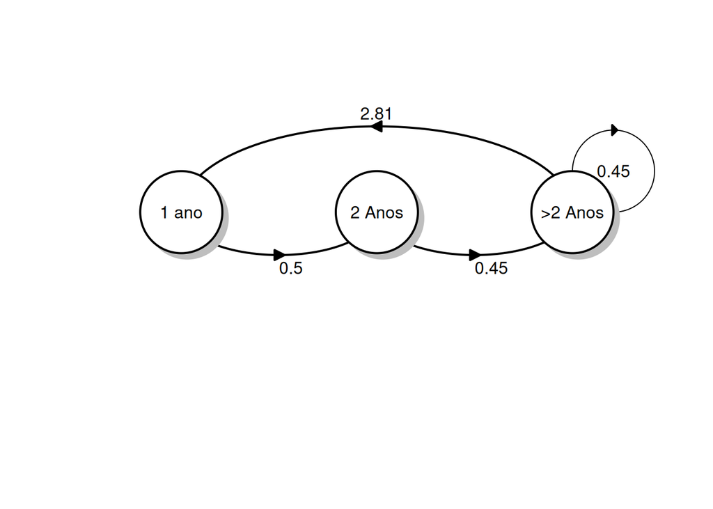

```r
diagram::plotmat(A = A, pos=3, curve = 0.4, name = name, lwd = 2,
 arr.len = 0.2, arr.width = 0.2, my = .1,
 box.size = 0.07, arr.type = "triangle", dtext = .3,cex.txt=1,
 main = NULL)
```

### Usos do MPM

#### Projetando a população no tempo

Vamos primeiro criar uma condição inicial para a nossa população configurando a quantidade de organismos em cada classe etária

```r
#N0=round(stable.stage(A)*(100+round(rnorm(3,70,50),0)),0)
N0=round(10*abs(rnorm(3,1,10)),0)
```

| Classes | N0 |
| --- | --- |
| 1 ano | 80 |
| 2 anos | 150 |
| >2 anos | 50 |

Projeta a população do tempo *t* para o tempo *t+1*

```r
N1= A%*%N0
```

relembre que isso é uma simplificação então tudo bem ter 0,5 individuos! Para deixarmos o processo mais realista cabe a nós arrendondarmos os valores quando for pertinente! Para isso utilizandos a função “round

```r
round(N1,0)
```

| Classes | N0 | N1 |
| --- | --- | --- |
| 1 ano | 80 | 140 |
| 2 anos | 150 | 40 |
| >2 anos | 50 | 90 |

E podemos projetar mais uma vez

```r
N2= A%*%N1
round(N2)
```

| Classes | N0 | N1 | N2 |
| --- | --- | --- | --- |
| 1 ano | 80 | 140 | 253 |
| 2 anos | 150 | 40 | 70 |
| >2 anos | 50 | 90 | 58 |

Também podemos projetar o tamanho populacional quantas vezes quizermos utilizando o pacote *popbio*

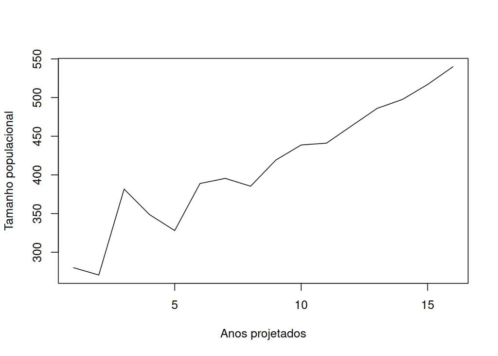

```r
futuro<-pop.projection(A,N0, 16)
plot(futuro$pop.sizes,type="l",
     xlab="Anos projetados",
     ylab="Tamanho populacional")
```

|  | Classes | N0 | N1 | N2 | N3 | N4 | N5 | N6 | N7 | N8 | N9 | N10 | N11 | N12 | N13 | N14 | N15 |
| --- | --- | --- | --- | --- | --- | --- | --- | --- | --- | --- | --- | --- | --- | --- | --- | --- | --- |
| 1 ano | 1 ano | 80 | 140 | 253 | 164 | 163 | 233 | 209 | 197 | 236 | 238 | 232 | 254 | 265 | 266 | 280 | 293 |
| 2 Anos | 2 anos | 150 | 40 | 70 | 126 | 82 | 81 | 117 | 104 | 98 | 118 | 119 | 116 | 127 | 132 | 133 | 140 |
| >2 Anos | >2 anos | 50 | 90 | 58 | 58 | 83 | 74 | 70 | 84 | 85 | 82 | 90 | 94 | 95 | 100 | 104 | 107 |

O gráfico e a tabela acima são excelentes exemplos para discutirmos a idéia de estrutura etária estável. Isso porque tanto o crescimento do gráfico começa a estabilizar a partir do 5-6 ano assim como a proporção de indivíduos em cada classe etária passa a sofrer quase nenhuma mudança.Podemos utilizar a função `stable.stage()` se quisermos verificar a proporção de individíduos em cada classe etária e plotar essa proporção ao longo do tempo usando `stage.vector.plot()`

```r
stable.stage(A)
```

```
    1 ano    2 Anos   >2 Anos
0.5402043 0.2603546 0.1994411
```

[output not shown]

Também podemos avaliar o crescimento populacional de forma bastante objetiva aqui.

```r
lambda(A)
```

Uma vez que o $\lambda >1$ podemos concluir que a população está crescendo apesar de que numa velocidade bastante baixa.

As mesmas operações feitas por meio de uma única linha de comando podem ser feitas de forma detalhada passo a passo caso haja interesse de se aprofundar nos processos matemáticos explicados no apêndice 1 desse artigo.

```r
#ou utilizando as fórmulas matriciais
ev <- eigen(A)                      #Calcula os autovalores e autovetores associados a cada autovalor
lmax <- which.max(Re(ev$values))    #Identifica o autovalor dominante (maior valor)


#Retorna o valor de lambda
print("Lambda")
```

```
[1] "Lambda"
```

```r
round(ev$values[lmax],3)
```

```
[1] 1.037+0i
```

```r
W <- ev$vectors                     #separa os autovetores dos autovalores
w <- abs(Re(W[, lmax]))             #extrai o autovetor associado ao autovalor dominante
print("Estrutura etária estável")
```

```
[1] "Estrutura etária estável"
```

```r
round(w/sum(w),2)
```

```
[1] 0.54 0.26 0.20
```

```r
                            #Uma vez extraido o autovetor precisamos reescalona-lo para que ele represente de fato a proporção de indivíduos em cada classe etária
```

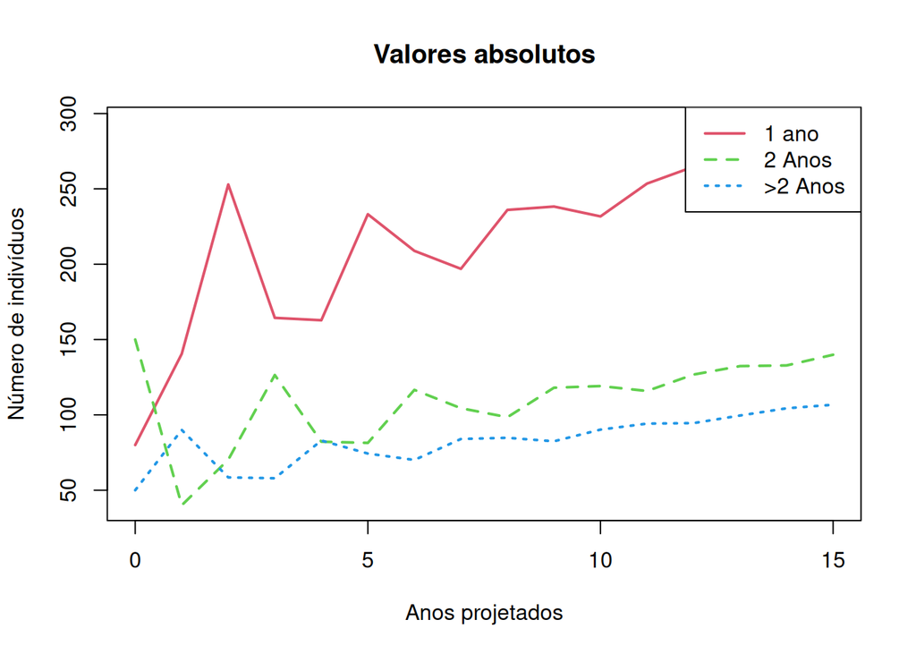

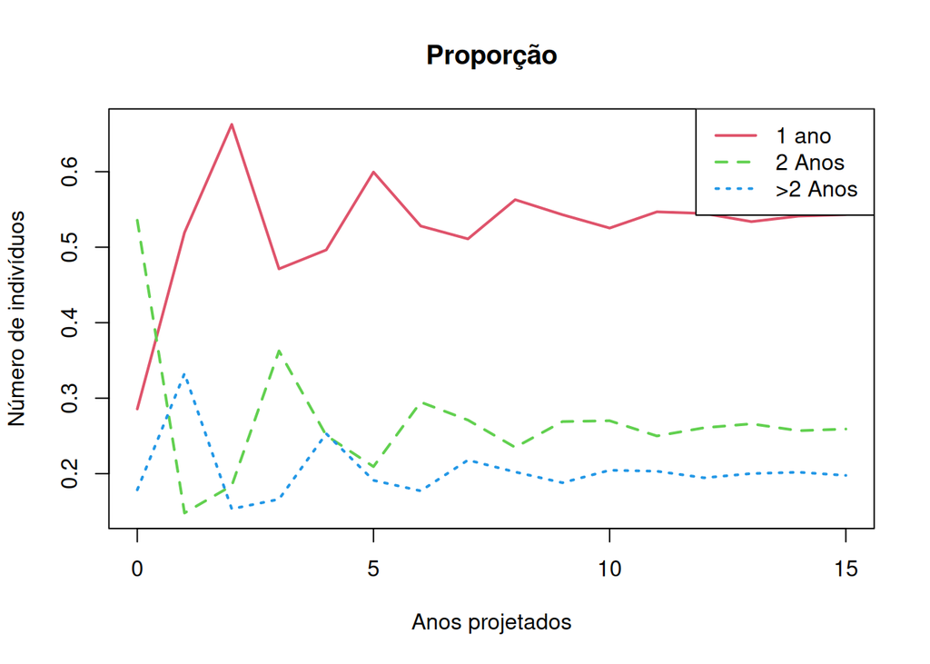

```r
par(mrow=c(1,2))
stage.vector.plot(futuro$stage.vectors,proportions = FALSE, col=2:4,main="Valores absolutos",xlab="Anos projetados",ylab="Número de indivíduos")
stage.vector.plot(futuro$stage.vectors,proportions = TRUE, col=2:4,main="Proporção",xlab="Anos projetados",ylab="Número de indivíduos")
```

Vamos sobrepor a projeção populacional utilizando a estrutura etária estável contra a projeção do crescimento populacional observada. A idéia aqui é relembrar como chegamos no conceito de autovalor e autovetor apresentado na equação 3 e 4 do apêndice 1.

$A*w = \lambda * w$ ou $(A-\lambda I)*w = 0$

```r
#Vamos utilizar a quantidade de indivíduos projetadas até o 15º ano.
#Aqui temos certeza que a população já alcançaou a estrutura etária estável!
futuro$stage.vectors[,15]
```

```
   1 ano   2 Anos  >2 Anos
279.8074 132.8127 104.3699
```

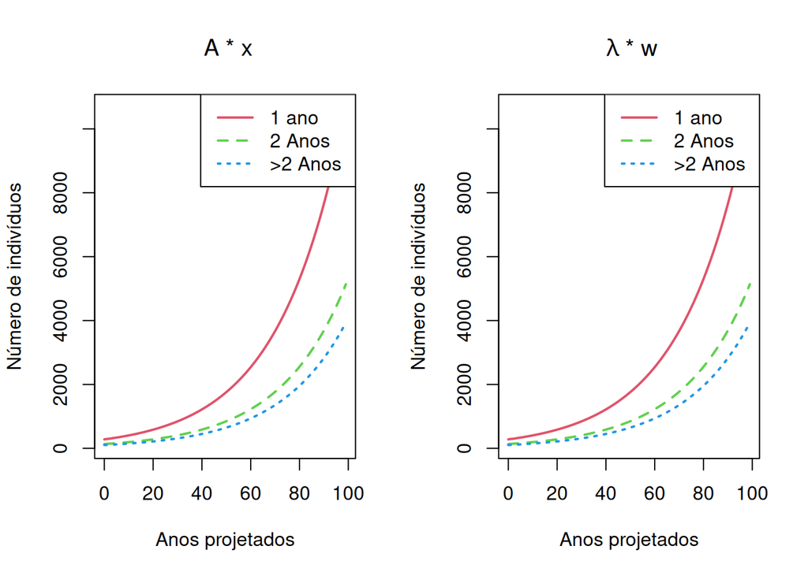

```r
#Vamos criar um objeto para armazenar a projeção dessa população para os próximos 100 anos
trajetoria.observada<-pop.projection(A,futuro$stage.vectors[,15],100)$stage.vectors


#E por fim vamos criar um objeto para armazenar a projeção dessa populaçao utilizando apenas o conceito matemático do autovalor dominante e autovetor.
#Aqui é importante ter em mente que a estrutura etária soma 1 então precisamos colocar essa estrutura etária numa escala semelhante.
#Isso foi feito multiplicando a estrutura etária pelo número de indivíduos totais projetados até o ano 15 com o comando abaixo:
#"stable.stage(A)*sum(futuro$stage.vectors[,15]),100)$stage.vectors"

trajetoria.autovalor.estruturaestavel<-pop.projection(lambda(A),
      stable.stage(A)*sum(futuro$stage.vectors[,15]),100)$stage.vectors


par(mfrow=c(1,2))
stage.vector.plot(trajetoria.observada,proportions = FALSE, col=2:4,
      xlab="Anos projetados",ylab="Número de indivíduos")
title(expression(""~A~"* x"))

stage.vector.plot(trajetoria.observada,proportions = FALSE, col=2:4,
      xlab="Anos projetados",ylab="Número de indivíduos")
title(expression(""~lambda~"* w"))
```

```r
#Você pode simplesmente remover o termo #"*sum(futuro$stage.vectors[,15]),100)$stage.vectors".
#Você vai ver que a trajetória continua exatamente a mesma
#apesar dos eixos y estarem em escalas diferentes.
```

### Outras aplicações do MPM

##### Por fim, vamos demonstar alguns comandos representados na tabela 1 do apêndice 1.

você pode buscar muito mais aplicações utilizando a função help do pacote popbio.Lá é possivel consultar várias aplicações demonstradas nos livros Caswell (2001) e Morris e Doak (2002).

```r
help(popbio)
```

#### R0

```r
net.reproductive.rate(A)
```

```
[1] 1.149545
```

#### Generation time

```r
generation.time(A)
```

```
[1] 3.791696
```

#### Damping ratio

```r
damping.ratio(A)
```

```
[1] 1.328927
```

#### Sensitivitidade e elasticidade

##### Opção 1: por derivada parcial

###### Sensitividade

```r
sens(A)
```

##### Elasticidade

```r
elasticity(A)
```

##### Opção 2: Por iteração

```r
#Criamos um vetor com as perturbações que iremos aplicar nos elementos da matriz
perturb<-seq(0.01,.99,0.01)

#Criamos também algumas matrizes onde iremos armazenar as mudanças feitas
new.mx<-SensOfLambda<-matrix(NA,nrow=dim(A)[1]^2,ncol=length(perturb))
```

```r
for (i in 1:dim(A)[1]^2){
    for(j in 1:length(perturb)){
A2<-A
if (A[[i]]==0) {
NULL
} else {
A2[[i]]<-perturb[j]
 new.mx[[i]]<-A2[[i]]
 SensOfLambda[i,j]<-lambda(A2)}
#print(j)
}
#print(i)
}

colnames(SensOfLambda)<-perturb
rownames(SensOfLambda)<-paste(c("s11","s21","s31","F12","s22","s32", "F13", "F23", "s33"))
```

Pronto, agora podemos demonstrar gráficamente essas mudanças

```r
SensOfLambda
```

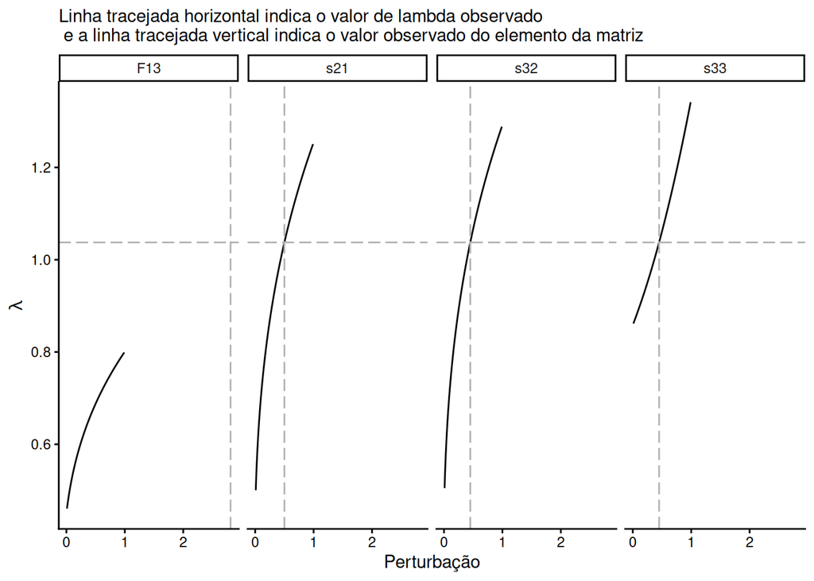

```r
#Primeiro precisamos construir uma tabela para armazenar todas as informações em um único ambiente
as.data.frame(              #Transforma o contjunto de dados em uma tabela
  cbind(                    #Concatena (junta) as seguintes tabelas:
    SensOfLambda,           #SensOfLambda = aqui foi armazenada o resultado de lambda calculado para cada observação
    Observado=as.vector(A)))%>%   #as.vector(A) serve para extrair os valores observados em cada elemento da matriz que será importante para marcar os valores observados em cada um dos gráficos que serão gerados abaixo
tibble::rownames_to_column(var = "Elementos")%>%
pivot_longer(!c(Elementos,Observado),names_to = "Perturbação", values_to = "Lambda")%>%
filter(Lambda != "NA")%>%
as.data.frame()%>%
mutate(Perturbação=as.numeric(Perturbação))%>%
mutate(Lambda.observado=lambda(A))%>%
ggplot(., aes(x=Perturbação,y=Lambda))+
geom_line()+
  geom_hline(yintercept = lambda(A),linetype="longdash",col="gray70")+
  geom_vline(aes(xintercept = Observado),linetype="longdash",col="gray70")+
ylab(expression(""~lambda~""))+
  facet_grid(.~Elementos,scales="free_y")+
theme_classic()+
 labs(subtitle = "Linha tracejada horizontal indica o valor de lambda observado \n e a linha tracejada vertical indica o valor observado do elemento da matriz")
```

Note também que a relação entre a mudança de um parámetro frequentemente é não linear. A magnitude e forma dessa curvatura (côncava - $\cap$ ;Convexa - $\cup$ ) pode ser acessada a partir da derivada parcial de segunda ordem. Scripts para isso podem ser acessado no pacote [demogR](https://cran.r-project.org/web/packages/demogR/index.html) e algumas aplicações ecológicas e para manejo podem ser encontradas em [Carslake et al. 2009](https://besjournals.onlinelibrary.wiley.com/doi/full/10.1111/j.1365-2656.2009.01569.x) e [Santos et al.2021 2021](https://www.biorxiv.org/content/10.1101/2021.04.12.439165v2) para aplicações evolutivas.

> NOTA: O uso da derivada parcial para calcular a sensitividade e elasticidade assume uma relação linear entre os valores dos elementos da matriz e a sua contribuição para o crescimento populacional. Como vimos no gráfico acima essa relação raramente é linear e por isso é importante ter em mente que as análises de perturbação são realistas apenas quando a perturbação é muito pequena (geralmente infinitesimal).

### Figuras

Abaixo fornecemos os códigos para a elaboração de cada figura. As legendas para cada figura podem ser encontradas no texto principal e por isso não serão repetidas aqui

##### Figura 2

```r
#=========================================================================
#       FIGURA 2
#=========================================================================
estoc<-round(rnorm(3,50,20),0)
#estoc<-c(28, 64, 59, -2)   #Gerado com a função acima!

lambda(A)
```

```
[1] 1.03744
```

```r
N0<-stable.stage(A)*(100+estoc)
A%*%floor(N0)
```

```
         [,1]
1 ano   75.87
2 Anos  41.00
>2 Anos 28.80
```

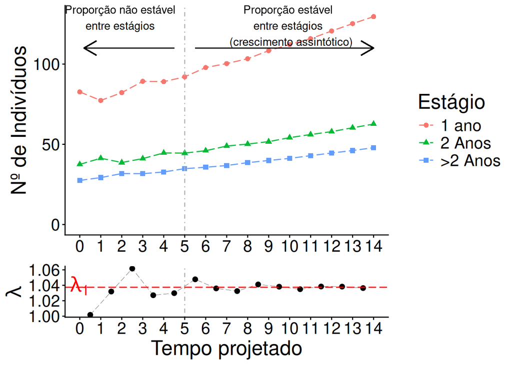

```r
#plot(pop.projection(A,N0, 15)$pop.changes,type="l")
#abline(h=lambda(A))
projecao<-pop.projection(A,N0, 15)
proj.vec<-t(projecao$stage.vectors)

colnames(proj.vec)<-c("1 ano","2 Anos",">2 Anos")

proj.vec<-reshape2::melt(proj.vec)
    colnames(proj.vec)<-c("t","Estágio","N")

#-------------------------------------------------------------
#   TOP
#-------------------------------------------------------------

TOP<-ggplot(proj.vec,aes(y=N,x=t,group=Estágio))+
geom_line(aes(color=Estágio),size=.5,type=2,linetype="longdash")+
geom_point(aes(color=Estágio,shape=Estágio),size=2)+
geom_segment(aes(x = 4.5, y = 110, xend = 0.2, yend = 110),
                  arrow = arrow(length = unit(0.5, "cm")))+
geom_segment(aes(x = 5.5, y = 110, xend = 14, yend = 110),
                  arrow = arrow(length = unit(0.5, "cm")))+
annotate("text", x = 10, y = 124, label = "Proporção estável \nentre estágios \n (crescimento assintótico)")+
annotate("text", x = 2, y = 124, label = "Proporção não estável \nentre estágios \n ")+
xlab(NULL)+
ylab("Nº de Indivíduos")+
ylim(0,130)+
 scale_x_continuous(limits = c(0, 14),breaks=c(0:14))+
geom_vline(xintercept=5,linetype="dotdash",color="gray70")+
theme_classic()+
theme(text=element_text(size=20))
#TOP
#-------------------------------------------------------------
# BOTTOM
#-------------------------------------------------------------
df.changes<-data.frame(Changes=c(pop.projection(A,N0, 15)$pop.changes),Time=c(1:14))

BOTTOM<-
ggplot(df.changes,aes(y=Changes,x=Time-.5))+
geom_line(size=.1,type=2,linetype="longdash")+
geom_point(size=2)+
 scale_x_continuous(limits = c(0, 14),breaks=c(0:14))+
xlab("Tempo projetado")+
ylab(expression(""~lambda~""))+
#ylim(0,120)+
geom_vline(xintercept=5,linetype="dotdash",color="gray70")+
geom_hline(yintercept=lambda(A),linetype="longdash",color="red")+
annotate("text", size = 7,col="red",,x = 0.01, y = lambda(A)+0.002, parse = TRUE, label =as.character(expression(paste("",lambda[1],""))))+
theme_classic()+
theme(text=element_text(size=20))
#BOTTOM
#-------------------------------------------------------------

legend <- get_legend(
  # create some space to the left of the legend
  TOP + theme(legend.box.margin = margin(0, 0, 0, 12))
)

plots <- align_plots(TOP+theme(legend.position="none"), BOTTOM, align = 'v', axis = 'l')
bottom_row <- plot_grid(plots[[2]],  nrow = 1)

plot_grid(plots[[1]], legend,bottom_row,NULL,rel_widths = c(1, .3),rel_heights = c(1, .4),ncol = 2)

cowplot::plot_grid(align_plots(TOP, BOTTOM, align = 'v', axis = 'l'))
```

##### Figura 6

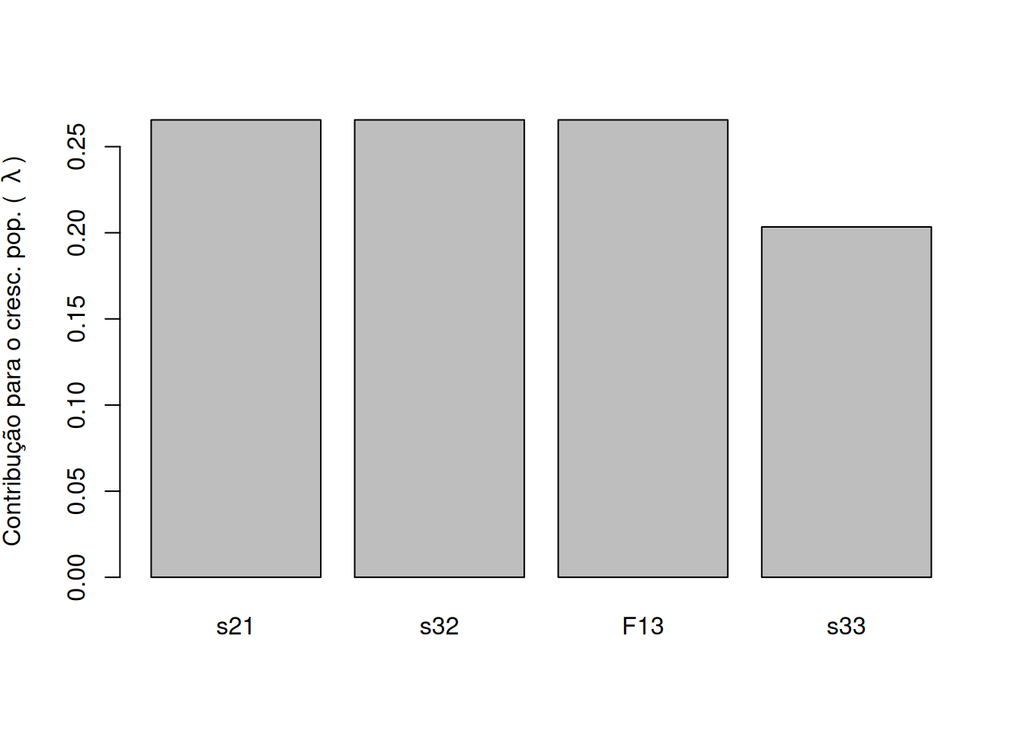

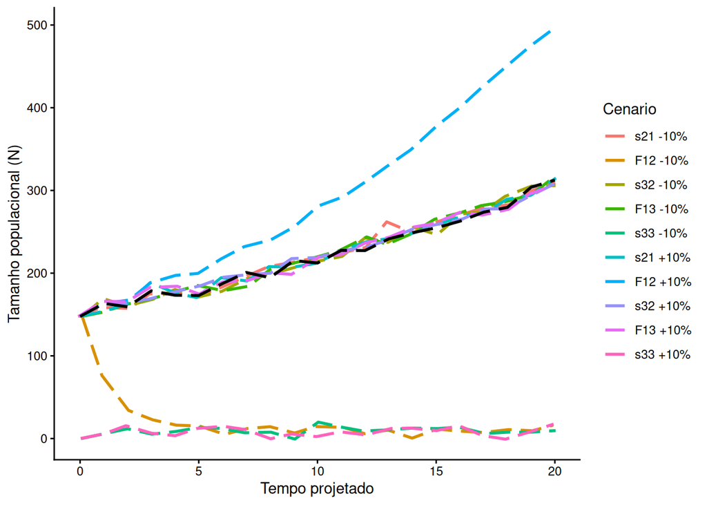

```r
#=========================================================================
#       Figura 6 - LTRE x Pfister plot
#=========================================================================
df<-data.frame(as.numeric(as.vector(sensitivity(A))),
as.numeric(as.vector(elasticity(A))),
(c("s11","s21","s31","F12","s22","s32", "F13", "F23", "s33")))
colnames(df)<-c("sensibilidade", "elasticidade","classes")
df$sensibilidade[df$elasticidade==0]<-0
df<-subset(df,elasticidade>0)
rownames(df)<-df$classes


nonzero<-length(A[A>0])
labels<-(c("s11","s21","s31","F12","s22","s32", "F13", "F23", "s33"))
nonzero.labels<-labels[AA>0]

projecoes.menos<-projecoes.mais<-matrix(0,ncol=5,nrow=50)


for (i in 1: nonzero){
  A2<-A
if(A2[i]>0){
A2[i]<-A2[i]+(A2[i]/10)
    }else{(NULL)}
projecoes.mais[,i]<-pop.projection(A2,N0, 50)$pop.sizes
}
colnames(projecoes.mais)<-paste(nonzero.labels,"+10%")


#------------------------------------------------------------
#   SIMULANDO REDUÇÃO DE -10%
#------------------------------------------------------------
for (i in 1: nonzero){
  A2<-A
if(A2[i]>0){
A2<-A2[i]-(A2[i]/10)
    }else{(NULL)}
projecoes.menos[,i]<-pop.projection(A2,N0, 50)$pop.sizes
}

colnames(projecoes.menos)<-paste(nonzero.labels,"-10%")

df.proj<-data.frame(
    pop.projection(A,N0, 50)$pop.sizes,
    cbind(projecoes.menos,projecoes.mais))

colnames(df.proj)<-c("projecao",
            colnames(projecoes.menos),
            colnames(projecoes.mais))

df.proj<-reshape2::melt(df.proj)
    colnames(df.proj)<-c("Cenario","N")

df.proj$time<-as.vector(replicate(11,0:49))


df.proj2<-df.proj
for(i in 1:dim(df.proj)[1]){
if(df.proj$time[i] > 0){
    df.proj2$N[i]<-df.proj$N[i]+rnorm(1,10,5)
    }
}

barplot(df[,2],names.arg=df$classes,ylab=expression("Contribução para o cresc. pop. ( "~lambda~")"))

ggplot(subset(df.proj2[-c(1:21),],time<21),aes(y=N,x=time,group=Cenario))+
geom_line(aes(color=Cenario),size=1,linetype="longdash",
    position=position_jitter(w=.1, h=.1))+
  xlab("Tempo projetado")+
  ylab("Tamanho populacional (N)")+
geom_line(data=df.proj2[1:21,],color="black",size=1,linetype="longdash")+
  theme_classic()
```

##### Figura 7

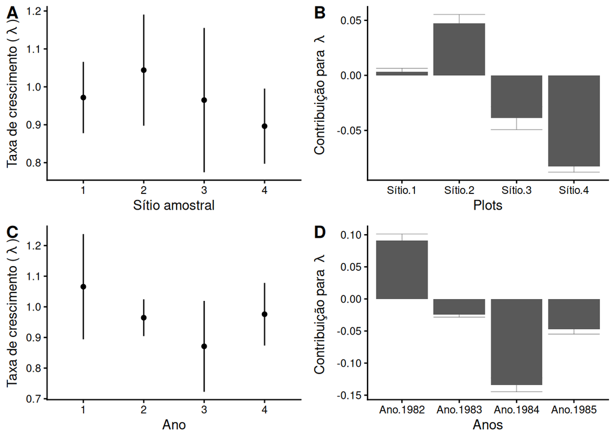

```r
#=========================================================================
#       Figura 7 - LTRE
#=========================================================================
data(calathea)

#-----------------------------------
#Contribuição dos sítios amostrais
#-----------------------------------
plots.lamb<-lapply(calathea[-17],lambda)

df<-data.frame(lambda=unlist(
lapply(lapply(split(plots.lamb, rep(1:4,each=4)),unlist),mean)),
            sd=
unlist(lapply(lapply(split(plots.lamb, rep(1:4,each=4)),unlist),sd)))

lambs<-ggplot(df,aes(y=lambda,x=rownames(df)))+
geom_point()+
geom_linerange(aes(ymin=lambda-sd,ymax=lambda+sd))+
theme_classic()+xlab("Sítio amostral")+ylab("Taxa de crescimento ("~lambda~")")

#-----------------------------------
#Contribuição da variação anual
#-----------------------------------

lambs.anual<-data.frame(
lambda=unlist(
    lapply(lapply(
        split(plots.lamb, rep(1:4,4)),unlist),mean)),
sd=unlist(
    lapply(lapply(
        split(plots.lamb, rep(1:4,4)),unlist),sd)))%>%
ggplot(aes(y=lambda,x=rownames(df)))+
geom_point()+
geom_linerange(aes(ymin=lambda-sd,ymax=lambda+sd))+
theme_classic()+xlab("Ano")+ylab("Taxa de crescimento ("~lambda~")")

esquerda<-cowplot::plot_grid(lambs,lambs.anual,ncol=1,labels=c("A","C"))

#-----------------------------------
#LTRE
#-----------------------------------
#script retirado de help(LTRE) do pacote popbio

data(calathea)
calathea_pool<-calathea[['pooled']]

plots<- split(calathea[-17], rep(1:4,each=4))
plots<- lapply(plots, mean)
Cm<-LTRE(plots, calathea_pool)
pe<-sapply(Cm, sum)

##YEARS -- split recycles vector
yrs<-split(calathea[-17], 1:4)
yrs <- lapply(yrs, mean)
names(yrs)<-1982:1985
Cm<-LTRE(yrs, calathea_pool)
ye<-sapply(Cm, sum)

#=========================================================================
#       INTERVALO DE CONFIANÇA PARA AS ANÁLISES DE LTRE
#=========================================================================
##YEARS -- split recycles vector

yrs<-split(calathea[-17], 1:4)

years.LTRE<-matrix(nrow=100,ncol=length(yrs),dimnames=list(NULL,paste ("Ano",1982:1985)))
 for(i in 1:length(yrs)){
years.LTRE[,i]<-replicate(100,sum(LTRE(mean(sample(yrs[[i]])[-1]), calathea_pool)))
}


##PLOTS -- split recycles vector

plots<- split(calathea[-17], rep(1:4,each=4))

plots.LTRE<-matrix(nrow=100,ncol=length(plots),dimnames=list(NULL,paste ("Sítio",1:4)))
 for(i in 1:length(plots)){
plots.LTRE[,i]<-replicate(100,sum(LTRE(mean(sample(plots[[i]])[-1]), calathea_pool)))
}


plot.LTRE.sitios<-gather(data.frame(plots.LTRE))%>%
ggplot(aes(x=key, y=value)) +
#    geom_col()+
 stat_summary(fun.data = mean_cl_normal, geom = "errorbar", mult = 1,size=.1)+
 stat_summary(fun.y = mean, geom = "bar") +
xlab("Plots")+
ylab("Contribuição para " ~lambda~ "")+
theme_classic()
plot.LTRE.anos<-gather(data.frame(years.LTRE))%>%
ggplot(aes(x=key, y=value)) +
#    geom_col()+
 stat_summary(fun.data = mean_cl_normal, geom = "errorbar", mult = 1,size=.1)+
 stat_summary(fun.y = mean, geom = "bar") +
xlab("Anos")+
ylab("Contribuição para " ~lambda~ "")+
theme_classic()
cowplot::plot_grid(esquerda,
cowplot::plot_grid(plot.LTRE.sitios,plot.LTRE.anos,ncol=1,labels=c("B","D")))
```

##### Figura 8

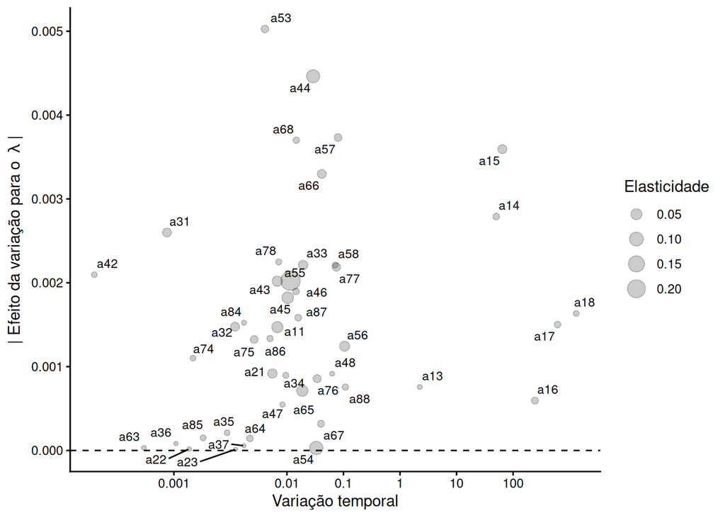

```r
#=========================================================================
#       Figura 8 - LTRE
#=========================================================================
x <- dim(calathea[[1]])[1]      #dimensão da matriz
data.frame(
    Parametros = as.vector(calathea_pool),
    Efeito=as.vector(mean(LTRE(lapply(yrs, mean),calathea_pool))),
    Variacao=as.vector(mean(lapply(yrs, var2))),
    elementos.matriz=paste("a", 1:x, rep(1:x, each = x), sep = ""),
    #variable="Efeito",
    Sensitivity=as.vector(popdemo::sens(calathea_pool)),
    Elasticity=as.vector(elasticity(calathea_pool)))%>%
filter(Parametros != 0)%>%
ggplot(aes(x=Variacao,y=abs(Efeito),label=elementos.matriz))+
geom_point(aes(size=Elasticity),alpha=.2)+
#geom_text(size=3)+
geom_text_repel(size=3)+
scale_x_log10(breaks=c(0.0001,0.01,0.1,1,10,100),labels=c(0.001,0.01,0.1,1,10,100))+
#scale_y_log10()+
xlab("Variação temporal")+
labs(size="Elasticidade")+
geom_hline(yintercept=0,linetype="dashed")+     #geom_hline(yintercept, linetype, color, size)
ylab("| Efeito da variação para o " ~lambda~ "|")+theme_classic()
```

##### Figura 9

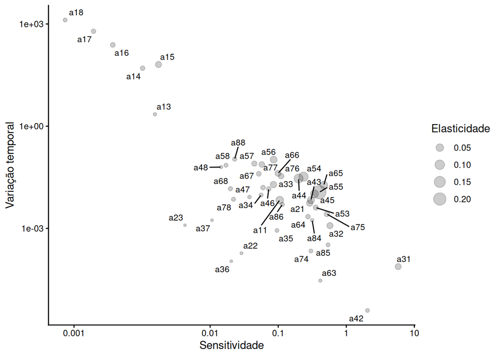

```r
#=========================================================================
#       Figura 9 - Demographic buffering hypothesis
#=========================================================================
data.frame(
    Parametros = as.vector(calathea_pool),
    Efeito=as.vector(mean(LTRE(lapply(yrs, mean),calathea_pool))),
    Variacao=as.vector(mean(lapply(yrs, var2))),
    elementos.matriz=paste("a", 1:x, rep(1:x, each = x), sep = ""),
    #variable="Efeito",
    Sensitivity=as.vector(popdemo::sens(calathea_pool)),
    Elasticity=as.vector(elasticity(calathea_pool)))%>%
filter(Parametros != 0)%>%
ggplot(aes(x=Sensitivity,y=Variacao,label=elementos.matriz))+
geom_point(aes(size=Elasticity),alpha=.2)+
#geom_text(size=3)+
geom_text_repel(size=3)+
scale_x_log10(breaks=c(0.0001,0.01,0.1,1,10,100),labels=c(0.001,0.01,0.1,1,10,100))+
scale_y_log10()+

  xlab("Sensitividade")+
labs(size="Elasticidade")+
#geom_hline(yintercept=0,linetype="dashed")+        #geom_hline(yintercept, linetype, color, size)
ylab("Variação temporal")+theme_classic()
```

### Metadados COMADRE & COMPADRE

```r
comadre$metadata%>%
as_tibble()%>%
filter(Continent == "S America")%>%
distinct(Authors,.keep_all = TRUE)%>%
select(-c( Genus:AngioGymno, AdditionalSource:MatrixPopulation,Altitude,Ecoregion:SurvivalIssue))
```

Metadados COMADRE filtrado para América do Sul

| MatrixID | SpeciesAuthor | SpeciesAccepted | CommonName | Kingdom | Phylum | Class | Order | Family | Authors | Journal | SourceType | OtherType | YearPublication | DOI_ISBN | NumberPopulations | Lat | Lon | Country | Continent | _Database | _PopulationStatus | _PublicationStatus |
| --- | --- | --- | --- | --- | --- | --- | --- | --- | --- | --- | --- | --- | --- | --- | --- | --- | --- | --- | --- | --- | --- | --- |
| 240307 | Alouatta_seniculus | Alouatta seniculus | Red howler | Animalia | Chordata | Mammalia | Primates | Atelidae | Wiederholt; Fernandez-Duque; Diefenbach; Rudran | Ecol Model | Journal Article | NA | 2010 | 10.1016/j.ecolmodel.2010.06.026 | 2 | 8.566667 | -67.58333 | VEN | S America | COMADRE | Released | Released |
| 240323 | Ara_glaucogularis_2 | Ara glaucogularis | Blue-throated macaw | Animalia | Chordata | Aves | Psittaciformes | Psittacidae | Maestri; Ferrati; Berkunsky | Ecol Model | Journal Article | NA | 2017 | 10.1016/j.ecolmodel.2017.07.023 | 1 | -14.378333 | -65.09583 | BOL | S America | COMADRE | Released | Released |
| 240508 | Physeter_macrocephalus | Physeter macrocephalus | Sperm whale | Animalia | Chordata | Mammalia | Cetacea | Physeteridae | Whitehead; Gero | Endanger Species Res | Journal Article | NA | 2015 | 10.3354/esr00657 | 1 | 14.233333 | -61.35000 | MTQ | S America | COMADRE | Released | Released |
| 248048 | Astroblepus_ubidiai | Astroblepus ubidiai | Andean catfish | Animalia | Chordata | Actinopterygii | Siluriformes | Astroblepidae | Vélez-Espino | Ecol Freshw Fish | Journal Article | NA | 2005 | 10.1111/j.1600-0633.2005.00084.x | 1 | 0.105833 | -78.22222 | ECU | S America | COMADRE | Released | Released |
| 248055 | Brachyrhaphis_rhabdophora | Brachyrhaphis rhabdophora | Live-bearing fish | Animalia | Chordata | Actinopterygii | Cyprinodontiformes | Poeciliidae | Johnson; Zúñiga-Vega | Ecology | Journal Article | NA | 2009 | 10.1890/07-1672.1 | 2 | 10.415833 | -85.09694 | CRI | S America | COMADRE | Released | Released |
| 248122 | Genypterus_blacodes | Genypterus blacodes | Pink cusk-eel | Animalia | Chordata | Actinopterygii | Ophidiiformes | Ophidiidae | Gonzales-Olivares; Aranguiz-Acuna; Ramos-Jiliberto; Rojas-Palma | Fish Res | Journal Article | NA | 2009 | 10.1016/j.fishres.2008.11.006 | 2 | -49.000000 | -77.00000 | CHL | S America | COMADRE | Released | Released |
| 248262 | Agaricia_agaricites | Agaricia agaricites | Tan lettuce-leaf coral | Animalia | Cnidaria | Anthozoa | Scleractinia | Agariciidae | Hughes; Tanner | Ecology | Journal Article | NA | 2000 | 10.1890/0012-9658(2000)081[2250:RFLHAL]2.0.CO;2 | 1 | NA | NA | JAM | S America | COMADRE | Released | Released |
| 248318 | Orbicella_annularis | Montastraea annularis | Caribbean star coral | Animalia | Cnidaria | Anthozoa | Scleractinia | Faviidae | Edmunds | Limnol Oceanogr | Journal Article | NA | 2015 | 10.1002/lno.10075 | 1 | 18.316667 | -64.72222 | VIR | S America | COMADRE | Released | Released |
| 248341 | Plexaura_A | Plexaura sp. | Gorgonian coral | Animalia | Cnidaria | Anthozoa | Alcyonacea | Plexauridae | Lasker | Oecologia | Journal Article | NA | 1991 | 10.1007/BF00318316 | 1 | 9.566667 | -78.81667 | PAN | S America | COMADRE | Released | Released |
| 248515 | Diomedea_melanophris | Thalassarche melanophris | Black-browed albatross | Animalia | Chordata | Aves | Procellariiformes | Diomedeidae | Arnold; Brault; Croxall | Ecol Appl | Journal Article | NA | 2006 | 10.1890/03-5340 | 1 | -54.006111 | -38.03556 | SGS | S America | COMADRE | Released | Released |
| 248553 | Forpus_passerinus | Forpus passerinus | Green-rumped parrotlets | Animalia | Chordata | Aves | Psittaciformes | Psittacidae | Sandercock; Beissinger | J Appl Stat | Journal Article | NA | 2002 | 10.1080/02664760120108818 | 1 | 8.566667 | -67.58333 | VEN | S America | COMADRE | Released | Released |
| 248957 | Homo_sapiens_subsp._sapiens | Homo sapiens | Human | Animalia | Chordata | Mammalia | Primates | Hominidae | Keyfitz; Flieger | NA | Book Chapter | NA | 1990 | 0-226-43237-8 | 14 | 10.650000 | -61.51667 | TTO | S America | COMADRE | Released | Released |
| 249048 | Panstrongylus_geniculatus | Panstrongylus geniculatus | NA | Animalia | Arthropoda | Insecta | Hemiptera | Reduviidae | Rabinovich; Feliciangeli | J Med Entomol | Journal Article | NA | 2015 | 10.1093/jme/tjv112 | 1 | NA | NA | VEN | S America | COMADRE | Released | Released |
| 249126 | Arctocephalus_australis | Arctocephalus australis | South american fur seal | Animalia | Chordata | Mammalia | Carnivora | Otariidae | Lima; Páez | J Mammal | Journal Article | NA | 1997 | 10.2307/1382951 | 1 | -35.027222 | -54.88194 | URY | S America | COMADRE | Released | Released |
| 249133 | Brachyteles_hypoxanthus | Brachyteles hypoxanthus | Northern muriqui | Animalia | Chordata | Mammalia | Primates | Atelidae | Morris; Altmann; Brockman; Cords; Fedigan; Pusey; Stoinski; Bronikowski; Alberts; Strier | Am Nat | Journal Article | NA | 2011 | 10.1086/657443 | 1 | -19.731111 | -41.41889 | BRA | S America | COMADRE | Released | Released |
| 249269 | Didelphis_aurita | Didelphis aurita | Common marsupial | Animalia | Chordata | Mammalia | Didelphimorphia | Didelphidae | Ferreira; Kajin; Vieira; Zangrandi; Cerqueira; Gentile | Mamm Biol | Journal Article | NA | 2013 | 10.1016/j.mambio.2013.03.002 | 1 | -22.046111 | -42.68917 | BRA | S America | COMADRE | Released | Released |
| 249379 | Hippocamelus_bisulcus | Hippocamelus bisulcus | Huemul deer | Animalia | Chordata | Mammalia | Artiodactyla | Cervidae | Corti; Wittmer; Festa-Bianchet | J Mammal | Journal Article | NA | 2010 | 10.1644/09-MAMM-A-047.1 | 3 | 47.200000 | -72.50000 | CHL | S America | COMADRE | Released | Released |
| 249384 | Lagothrix_lagothricha | Lagothrix lagotricha | Humboldt’s woolly monkey | Animalia | Chordata | Mammalia | Primates | Atelidae | Defler | NA | Book Chapter | NA | 2014 | 978-1-4939-0697-0 | 1 | 2.666667 | -74.16667 | COL | S America | COMADRE | Released | Released |
| 249785 | Pseudalopex_culpaeus | Lycalopex culpaeus | Andean fox | Animalia | Chordata | Mammalia | Carnivora | Canidae | Novaro; Funes; Walker | J Appl Ecol | Journal Article | NA | 2005 | 10.1111/j.1365-2664.2005.01067.x | 2 | -40.000000 | -71.00000 | ARG | S America | COMADRE | Released | Released |
| 249817 | Saguinus_fuscicollis | Saguinus fuscicollis | Saddlebacked tamarin | Animalia | Chordata | Mammalia | Primates | Callitrichidae | Watsa | NA | Thesis | NA | 2013 | 10.7936/K7DB7ZTD | 4 | -12.568611 | -70.09917 | PER | S America | COMADRE | Released | Released |
| 249963 | Oithona_hebes | Oithona hebes | Copepod | Animalia | Arthropoda | Maxillopoda | Cyclopoida | Oithonidae | Torres-Sorando; Zacarias; Zoppi de Roa; Rodríguez | Ecol Model | Journal Article | NA | 2003 | 10.1016/S0304-3800(02)00355-1 | 1 | 10.258333 | -65.80833 | VEN | S America | COMADRE | Released | Released |
| 249985 | Stratiodrilus_aeglaphilus | Stratiodrilus aeglaphilus | Freshwater crayfish | Animalia | Annelida | Polychaeta | Eunicida | Histriobdellidae | Pardo; Vila; Bustamante | Hydrobiologia | Journal Article | NA | 2008 | 10.1007/s10750-007-9136-8 | 2 | -33.740833 | -70.90000 | CHL | S America | COMADRE | Released | Released |
| 250117 | Podocnemis_lewyana | Podocnemis lewyana | Magdalena River Turtle | Animalia | Chordata | Reptilia | Testudines | Podocnemididae | Páez; Bock; Espinal-García; Rendón-Valencia; Alzate-Estrada; Cartagena-Otálvaro; Heppell | Copeia | Journal Article | NA | 2015 | 10.1643/CE-14-191 | 1 | NA | NA | COL | S America | COMADRE | Released | Released |
| 250118 | Podocnemis_expansa | Podocnemis expansa | Arrau turtle | Animalia | Chordata | Reptilia | Testudines | Podocnemididae | Mogollones; Rodríguez; Hernández; Barreto | Chelonian Conserv Bi | Journal Article | NA | 2010 | 10.2744/CCB-0778.1 | 1 | 6.430278 | -67.16250 | VEN | S America | COMADRE | Released | Released |

```r
compadre$metadata%>%
as_tibble()%>%
filter(Continent == "S America")%>%
distinct(Authors,.keep_all = TRUE)%>%
select(-c( Genus:AngioGymno, AdditionalSource:MatrixPopulation,Altitude,Ecoregion:SurvivalIssue))
```

Metadados COMPADRE filtrado para América do Sul

| MatrixID | SpeciesAuthor | SpeciesAccepted | CommonName | Kingdom | Phylum | Class | Order | Family | Authors | Journal | SourceType | OtherType | YearPublication | DOI_ISBN | NumberPopulations | Lat | Lon | Country | Continent | _Database | _PopulationStatus | _PublicationStatus |
| --- | --- | --- | --- | --- | --- | --- | --- | --- | --- | --- | --- | --- | --- | --- | --- | --- | --- | --- | --- | --- | --- | --- |
| 238284 | Betula_pendula | Betula pendula | Silver Birch | Plantae | Magnoliophyta | Magnoliopsida | Fagales | Betulaceae | Maillette | J Appl Ecol | Journal Article | NA | 1982 | 10.2307/2403005 | 1 | NA | NA | BRA | S America | COMPADRE | Released | Released |
| 238648 | Heteropsis_flexuosa | Heteropsis flexuosa | NA | Plantae | Magnoliophyta | Liliopsida | Alismatales | Araceae | Balcazar | NA | Thesis | NA | 2013 | 978-90-9027402-7 | 2 | -4.005833 | -69.89861 | COL | S America | COMPADRE | Released | Released |
| 238651 | Himatanthus_drasticus | Himatanthus drasticus | Plumel | Plantae | Tracheophyta | Magnoliopsida | Gentianales | Apocynaceae | Baldauf; Correa; Ferreira; Santos | Forest Ecol Manag | Journal Article | NA | 2015 | 10.1016/j.foreco.2015.06.022 | 4 | -7.183333 | -39.21667 | BRA | S America | COMPADRE | Released | Released |
| 239054 | Spathoglottis_plicata | Spathoglottis plicata | Philippine ground orchid; Philippine orchid; Large purple orchid | Plantae | Magnoliophyta | Liliopsida | Asparagales | Orchidaceae | Falcón; Ackerman; Tremblay | Biol Invasions | Journal Article | NA | 2017 | 10.1007/s10530-016-1318-8 | 1 | 18.349444 | -66.68444 | PRI | S America | COMPADRE | Released | Released |
| 239078 | Vellozia_aff._sincorana | Vellozia sinconara | Candomba | Plantae | Tracheophyta | Magnoliopsida | Pandanales | Velloziaceae | Souza; Schmidt; Conceicao | Flora | Journal Article | NA | 2017 | 10.1016/j.ﬂora.2017.02.007 | 8 | -12.628889 | -41.50444 | BRA | S America | COMPADRE | Released | Released |
| 239750 | Lepanthes_acuminata | Lepanthes acuminata | NA | Plantae | Magnoliophyta | Liliopsida | Asparagales | Orchidaceae | Raventós; García-González; Riverón-Giró; Damon | Plant Ecol Divers | Journal Article | NA | 2018 | 10.1080/17550874.2018.1444110 | 1 | 15.091944 | -92.16583 | MEX | S America | COMPADRE | Released | Released |
| 239913 | Lepanthes_caritensis_2 | Lepanthes caritensis | NA | Plantae | Magnoliophyta | Liliopsida | Asparagales | Orchidaceae | Tremblay | Selbyana | Journal Article | NA | 1997 | NA | 2 | 18.094167 | -66.02750 | PRI | S America | COMPADRE | Released | Released |
| 239915 | Lepanthes_rubripetala_2 | Lepanthes rubripetala | NA | Plantae | Magnoliophyta | Liliopsida | Asparagales | Orchidaceae | Schödelbauerová; Tremblay; Kindlmann | Biodivers Conserv | Journal Article | NA | 2010 | 10.1007/s10531-009-9724-1 | 8 | 18.294722 | -65.80000 | PRI | S America | COMPADRE | Released | Released |
| 240000 | Melocactus_bahiensis | Melocactus bahiensis | NA | Plantae | Magnoliophyta | Magnoliopsida | Caryophyllales | Cactaceae | Hughes; Figueira; Jacobi; Borba | Braz J Bot | Journal Article | NA | 2018 | 10.1007/s40415-018-0483-7 | 1 | -16.571111 | -41.48222 | BRA | S America | COMPADRE | Released | Released |
| 240773 | Andropogon_brevifolius | Schizachyrium brevifolium | NA | Plantae | Magnoliophyta | Liliopsida | Poales | Poaceae | Canales; Trevisan; Silva; Caswell | Acta Oecol | Journal Article | NA | 1994 | NA | 2 | 9.416667 | -68.25000 | VEN | S America | COMPADRE | Released | Released |
| 241123 | Aspasia_principissa | Aspasia principissa | NA | Plantae | Magnoliophyta | Liliopsida | Asparagales | Orchidaceae | Zotz; Schmidt | Biol Conserv | Journal Article | NA | 2006 | 10.1016/j.biocon.2005.07.022 | 1 | 9.166667 | -79.85000 | PAN | S America | COMPADRE | Released | Released |
| 241183 | Tillandsia_flexuosa | Tillandsia flexuosa | NA | Plantae | Magnoliophyta | Liliopsida | Poales | Bromeliaceae | Wester; Zotz | J Trop Ecol | Journal Article | NA | 2010 | 10.1017/S0266467409990459 | 1 | NA | NA | PAN | S America | COMPADRE | Released | Released |
| 241248 | Werauhia_sanguinolenta | Vriesea sanguinolenta | NA | Plantae | Magnoliophyta | Liliopsida | Poales | Bromeliaceae | Zotz | Acta Oecol | Journal Article | NA | 2005 | 10.1016/j.actao.2005.05.009 | 4 | 9.166667 | -79.85000 | PAN | S America | COMPADRE | Released | Released |
| 241375 | Aechmea_nudicaulis | Aechmea nudicaulis | Nurse bromeliad | Plantae | Magnoliophyta | Liliopsida | Poales | Bromeliaceae | Sampaio; Picó; Scarano | Am J Bot | Journal Article | NA | 2005 | 10.3732/ajb.92.4.674 | 12 | -22.204444 | -41.50028 | BRA | S America | COMPADRE | Released | Released |
| 241520 | Andropogon_semiberbis | Schizachyrium sanguineum | NA | Plantae | Magnoliophyta | Liliopsida | Poales | Poaceae | Silva; Raventós; Caswell; Trevisan | J Ecol | Journal Article | NA | 1991 | 10.2307/2260717 | 1 | 8.633333 | -70.20000 | VEN | S America | COMPADRE | Released | Released |
| 242041 | Calathea_marantifolia | Calathea marantifolia | NA | Plantae | Magnoliophyta | Liliopsida | Zingiberales | Marantaceae | Matlaga | NA | Thesis | NA | 2008 | NA | 1 | 8.480278 | -83.58944 | CRI | S America | COMPADRE | Released | Released |
| 242042 | Calathea_micans | Calathea micans | NA | Plantae | Magnoliophyta | Liliopsida | Zingiberales | Marantaceae | Le Corff; Horvitz | Ecol Model | Journal Article | NA | 2005 | 10.1016/j.ecolmodel.2005.05.009 | 1 | 10.433333 | -84.00000 | CRI | S America | COMPADRE | Released | Released |
| 243184 | Festuca_gracillima | Festuca gracillima | Tussock grass | Plantae | Magnoliophyta | Liliopsida | Poales | Poaceae | Oliva; Collantes; Humano | Rangeland Ecol Manag | Journal Article | NA | 2005 | 10.2111/1551-5028(2005)58[466:DOGTGP]2.0.CO;2 | 1 | -51.403611 | -69.62250 | ARG | S America | COMPADRE | Released | Released |
| 243551 | Heliconia_acuminata | Heliconia acuminata | NA | Plantae | Magnoliophyta | Liliopsida | Zingiberales | Heliconiaceae | Bruna | Ecology | Journal Article | NA | 2003 | 10.1890/0012-9658(2003)084[0932:APPIFH]2.0.CO;2 | 21 | -2.500000 | -60.00000 | BRA | S America | COMPADRE | Released | Released |
| 243598 | Heliconia_metallica | Heliconia metallica | NA | Plantae | Magnoliophyta | Liliopsida | Zingiberales | Heliconiaceae | Schleuning; Huamán; Matthies | J Ecol | Journal Article | NA | 2008 | 10.1111/j.1365-2745.2008.01416.x | 4 | -12.355556 | -70.71222 | PER | S America | COMPADRE | Released | Released |
| 244083 | Leptocoryphium_lanatum | Leptocoryphium lanatum | NA | Plantae | Magnoliophyta | Liliopsida | Poales | Poaceae | Raventós; Segarra; Acevedo | Ecol Model | Journal Article | NA | 2004 | 10.1016/j.ecolmodel.2003.12.044 | 1 | 8.633333 | -70.20000 | VEN | S America | COMPADRE | Released | Released |
| 244638 | Periandra_mediterranea | Periandra mediterranea | NA | Plantae | Magnoliophyta | Magnoliopsida | Fabales | Leguminosae | Hoffmann; Solbrig | Forest Ecol Manag | Journal Article | NA | 2003 | 10.1016/S0378-1127(02)00566-2 | 3 | -15.933333 | -47.88333 | BRA | S America | COMPADRE | Released | Released |
| 244659 | Phaseolus_lunatus | Phaseolus lunatus | Lima bean | Plantae | Magnoliophyta | Magnoliopsida | Fabales | Leguminosae | Degreef; Baudoin; Rocha | Genet Resour Crop Ev | Journal Article | NA | 1997 | 10.1023/A:1008623521755 | 1 | NA | NA | CRI | S America | COMPADRE | Released | Released |
| 245753 | Syngonanthus_nitens | Syngonanthus nitens | Golden-grass | Plantae | Magnoliophyta | Liliopsida | Poales | Eriocaulaceae | Schmidt; Ticktin | Biol Conserv | Journal Article | NA | 2012 | 10.1016/j.biocon.2012.03.018 | 9 | -1.050000 | -46.96667 | BRA | S America | COMPADRE | Released | Released |
| 246183 | Machaerium_cuspidatum | Machaerium cuspidatum | NA | Plantae | Magnoliophyta | Magnoliopsida | Fabales | Leguminosae | Nabe-Nielsen | J Trop Ecol | Journal Article | NA | 2004 | 10.1017/S0266467404001609 | 1 | 0.666667 | -76.38333 | ECU | S America | COMPADRE | Released | Released |
| 246189 | Astrocaryum_aculeatissimum | Astrocaryum aculeatissimum | NA | Plantae | Magnoliophyta | Liliopsida | Arecales | Arecaceae | Quitete-Portela; Bruna; dos Santos | Biodivers Conserv | Journal Article | NA | 2010 | 10.1007/s10531-010-9846-5 | 1 | NA | NA | BRA | S America | COMPADRE | Released | Released |
| 246199 | Attalea_humilis | Attalea humilis | NA | Plantae | Magnoliophyta | Liliopsida | Arecales | Arecaceae | Souza; Martins | Biodivers Conserv | Journal Article | NA | 2004 | 10.1023/B:BIOC.0000029326.44647.7f | 2 | -22.516667 | -42.28333 | BRA | S America | COMPADRE | Released | Released |
| 246314 | Euterpe_edulis | Euterpe edulis | NA | Plantae | Magnoliophyta | Liliopsida | Arecales | Arecaceae | Silva-Matos; Freckleton; Watkinson | Ecology | Journal Article | NA | 1999 | 10.1890/0012-9658(1999)080[2635:TRODDI]2.0.CO;2 | 1 | -22.829167 | -47.10917 | BRA | S America | COMPADRE | Released | Released |
| 246318 | Euterpe_edulis_2 | Euterpe edulis | NA | Plantae | Magnoliophyta | Liliopsida | Arecales | Arecaceae | Freckleton; Matos; Bovi; Watkinson | J Appl Ecol | Journal Article | NA | 2003 | 10.1046/j.1365-2664.2003.00842.x | 1 | -22.829167 | -47.10917 | BRA | S America | COMPADRE | Released | Released |
| 246319 | Euterpe_oleracea | Euterpe oleracea | NA | Plantae | Magnoliophyta | Liliopsida | Arecales | Arecaceae | Arango; Duque; Muñoz | Int J Trop Biol | Journal Article | NA | 2010 | 10.15517/rbt.v58i1.5222 | 3 | NA | NA | COL | S America | COMPADRE | Released | Released |
| 246325 | Euterpe_precatoria | Euterpe precatoria | NA | Plantae | Magnoliophyta | Liliopsida | Arecales | Arecaceae | Zuidema | NA | Book Chapter | NA | 2000 | 90-393-2524-3 | 1 | -10.983333 | -65.71667 | BOL | S America | COMPADRE | Released | Released |
| 246328 | Euterpe_precatoria_2 | Euterpe precatoria | NA | Plantae | Magnoliophyta | Liliopsida | Arecales | Arecaceae | Otárola; Avalos | Am J Bot | Journal Article | NA | 2014 | 10.3732/ajb.1400089 | 2 | 10.416667 | -84.00000 | CRI | S America | COMPADRE | Released | Released |
| 246333 | Geonoma_deversa | Geonoma deversa | NA | Plantae | Magnoliophyta | Liliopsida | Arecales | Arecaceae | Zuidema; de Kroon; Werger | Ecol Appl | Journal Article | NA | 2007 | 10.1890/1051-0761(2007)017[0118:TSBPAR]2.0.CO;2 | 2 | -11.750000 | -67.33333 | BOL | S America | COMPADRE | Released | Released |
| 246339 | Geonoma_macrostachys | Geonoma macrostachys | NA | Plantae | Magnoliophyta | Liliopsida | Arecales | Arecaceae | Svenning | Plant Ecol | Journal Article | NA | 2002 | 10.1023/A:1015520116260 | 1 | 0.666667 | -76.38333 | ECU | S America | COMPADRE | Released | Released |
| 246341 | Geonoma_orbignyana | Geonoma orbignyana | NA | Plantae | Magnoliophyta | Liliopsida | Arecales | Arecaceae | Rodríguez-Buriticá; Orjuela; Galeano | Forest Ecol Manag | Journal Article | NA | 2005 | 10.1016/j.foreco.2005.02.052 | 1 | 4.378611 | -74.06278 | COL | S America | COMPADRE | Released | Released |
| 246342 | Geonoma_schottiana | Geonoma schottiana | NA | Plantae | Magnoliophyta | Liliopsida | Arecales | Arecaceae | Sampaio; Scariot | J Trop Ecol | Journal Article | NA | 2010 | 10.1017/S0266467409990599 | 1 | -15.666667 | -47.98333 | BRA | S America | COMPADRE | Released | Released |
| 246347 | Iriartea_deltoidea | Iriartea deltoidea | Paxiuba barriguda | Plantae | Magnoliophyta | Magnoliopsida | Asparagales | Arecaceae | Pinard | Biotropica | Journal Article | NA | 1993 | 10.2307/2388974 | 6 | NA | NA | BRA | S America | COMPADRE | Released | Released |
| 246357 | Lepidocaryum_tenue | Lepidocaryum tenue | NA | Plantae | Magnoliophyta | Liliopsida | Arecales | Arecaceae | Navarro; Galeano; Bernal | Trop Conserv Sci | Journal Article | NA | 2011 | 10.1177/194008291100400104 | 1 | -4.005556 | -69.89861 | COL | S America | COMPADRE | Released | Released |
| 246358 | Mauritia_flexuosa | Mauritia flexuosa | Canangucho; Morete | Plantae | Magnoliophyta | Liliopsida | Arecales | Arecaceae | Holm; Miller; Cropper | Biotropica | Journal Article | NA | 2008 | 10.1111/j.1744-7429.2008.00412.x | 1 | 0.116667 | -76.18333 | ECU | S America | COMPADRE | Released | Released |
| 246362 | Phytelephas_seemannii | Phytelephas seemannii | NA | Plantae | Magnoliophyta | Liliopsida | Arecales | Arecaceae | Bernal | J Appl Ecol | Journal Article | NA | 1998 | 10.1046/j.1365-2664.1998.00280.x | 1 | NA | NA | COL | S America | COMPADRE | Released | Released |
| 246406 | Adesmia_volckmannii | Adesmia volckmannii | NA | Plantae | Magnoliophyta | Magnoliopsida | Fabales | Leguminosae | Cipriotti; Aguiar | Appl Veg Sci | Journal Article | NA | 2012 | 10.1111/j.1654-109X.2011.01138.x | 1 | -45.683333 | -70.26667 | ARG | S America | COMPADRE | Released | Released |
| 246602 | Fabiana_imbricata | Fabiana imbricata | NA | Plantae | Magnoliophyta | Magnoliopsida | Solanales | Solanaceae | Ruete | NA | Thesis | NA | 2006 | NA | 1 | -41.050000 | -71.03333 | ARG | S America | COMPADRE | Released | Released |
| 246663 | Miconia_albicans | Miconia albicans | NA | Plantae | Magnoliophyta | Magnoliopsida | Myrtales | Melastomataceae | Hoffmann | Ecology | Journal Article | NA | 1999 | 10.2307/177080 | 1 | -15.933333 | -47.88333 | BRA | S America | COMPADRE | Released | Released |
| 246964 | Espeletia_spicata | Coespeletia spicata | NA | Plantae | Magnoliophyta | Magnoliopsida | Asterales | Compositae | Silva; Trevisan; Estrada; Monosterio | Global Ecol Biogeogr | Journal Article | NA | 2000 | 10.1046/j.1365-2699.2000.00187.x | 1 | 8.866667 | -70.91667 | VEN | S America | COMPADRE | Released | Released |
| 247329 | Acacia_pennatula | Acacia pennatula | NA | Plantae | Magnoliophyta | Magnoliopsida | Fabales | Leguminosae | Somarriba | Agroforest Syst | Journal Article | NA | 2011 | 10.1007/s10457-011-9447-7 | 1 | 13.183333 | -86.26667 | NIC | S America | COMPADRE | Released | Released |
| 247349 | Actinostemon_concolor | Actinostemon concolor | NA | Plantae | Magnoliophyta | Magnoliopsida | Malpighiales | Euphorbiaceae | Bianchini; de Araújo; Green; Pimenta | Braz Arch Biol Technol | Journal Article | NA | 2013 | 10.1590/S1516-89132013000100009 | 1 | -23.450000 | -51.25000 | BRA | S America | COMPADRE | Released | Released |
| 247389 | Araucaria_araucana | Araucaria araucana | NA | Plantae | Pinophyta | Pinopsida | Pinales | Araucariaceae | Bekessy; Newton; Fox; Lara; Premoli; Cortes; Gonzalez; Burns; Gallo; Izquierdo; Burgman | NA | Book Chapter | NA | 2004 | NA | 1 | NA | NA | CHL | S America | COMPADRE | Released | Released |
| 247425 | Avicennia_germinans | Avicennia germinans | NA | Plantae | Magnoliophyta | Magnoliopsida | Lamiales | Acanthaceae | López-Hoffman; Ackerly; Anten; Denoyer; Ramos | J Ecol | Journal Article | NA | 2007 | 10.1111/j.1365-2745.2007.01298.x | 1 | 10.978333 | -71.73722 | VEN | S America | COMPADRE | Released | Released |
| 247429 | Bertholletia_excelsa | Bertholletia excelsa | Brazil nut tree | Plantae | Magnoliophyta | Magnoliopsida | Ericales | Lecythidaceae | Zuidema; Boot | J Trop Ecol | Journal Article | NA | 2002 | 10.1017/S0266467402002018 | 7 | NA | NA | BOL | S America | COMPADRE | Released | Released |
| 247453 | Callycophyllum_spruceanum | Calycophyllum spruceanum | Pau mulato | Plantae | Magnoliophyta | Magnoliopsida | Gentianales | Rubiaceae | Fortini; Zarin | Forest Ecol Manag | Journal Article | NA | 2010 | 10.1016/j.foreco.2010.11.007 | 1 | 0.021944 | -51.28500 | BRA | S America | COMPADRE | Released | Released |
| 247466 | Carapa_guianensis_2 | Carapa guianensis | Andiroba | Plantae | Magnoliophyta | Magnoliopsida | Sapindales | Meliaceae | Cropper; Klimas; Kainer; Wadt | Ecol Model | Journal Article | NA | 2012 | 10.1016/j.ecolmodel.2012.07.022 | 2 | -10.024444 | -67.70528 | BRA | S America | COMPADRE | Released | Released |
| 247526 | Cedrela_odorata | Cedrela odorata | Spanish cedar | Plantae | Magnoliophyta | Magnoliopsida | Sapindales | Meliaceae | Zuidema; Brienen; During; Guneralp | Am Nat | Journal Article | NA | 2009 | 10.1086/605981 | 16 | -11.400000 | -68.71667 | BOL | S America | COMPADRE | Released | Released |
| 247542 | Chlorocardium_rodiei | Chlorocardium rodiei | Greenheart | Plantae | Magnoliophyta | Magnoliopsida | Laurales | Lauraceae | ter Steege; Boot; Brouwer; Hammond; Vanderhout; Jetten; Khan; Polak; Raaimakers; Zagt | Ecol Appl | Journal Article | NA | 1995 | 10.2307/2269341 | 1 | 5.216667 | -58.80000 | GUY | S America | COMPADRE | Released | Released |
| 247552 | Dicorynia_guianensis | Dicorynia guianensis | NA | Plantae | Magnoliophyta | Magnoliopsida | Fabales | Leguminosae | Picard; Mortier; Chagneau | Ecol Model | Journal Article | NA | 2010 | 10.1016/j.ecolmodel.2010.06.010 | 1 | 5.266667 | -52.91667 | GUF | S America | COMPADRE | Released | Released |
| 247553 | Dicymbe_altsonii | Dicymbe altsonii | NA | Plantae | Magnoliophyta | Magnoliopsida | Fabales | Leguminosae | Zagt; Boot | NA | Thesis | NA | 1997 | NA | 1 | 5.225000 | -58.80833 | GUY | S America | COMPADRE | Released | Released |
| 247559 | Eperua_falcata | Eperua falcata | NA | Plantae | Magnoliophyta | Magnoliopsida | Fabales | Leguminosae | Chagneau; Mortier; Picard | J R Stat Soc C-Appl | Journal Article | NA | 2009 | 10.1111/j.1467-9876.2008.00657.x | 1 | 5.266667 | -52.91667 | GUF | S America | COMPADRE | Released | Released |
| 247572 | Grias_peruviana | Grias peruviana | NA | Plantae | Magnoliophyta | Magnoliopsida | Ericales | Lecythidaceae | Peters | NA | Book Chapter | NA | 1991 | 978-0231068925 | 1 | -4.216667 | -74.21667 | PER | S America | COMPADRE | Released | Released |
| 247575 | Guettarda_viburnoides | Guettarda viburnoides | NA | Plantae | Magnoliophyta | Magnoliopsida | Gentianales | Rubiaceae | Loayza; Knight | Ecology | Journal Article | NA | 2010 | 10.1890/09-0480.1 | 2 | -14.666667 | -66.41667 | BOL | S America | COMPADRE | Released | Released |
| 247684 | Pentaclethra_macroloba | Pentaclethra macroloba | NA | Plantae | Magnoliophyta | Magnoliopsida | Fabales | Leguminosae | Hartshorn | NA | Thesis | NA | 1972 | NA | 1 | 10.433333 | -83.98333 | CRI | S America | COMPADRE | Released | Released |
| 247833 | Prioria_copaifera | Prioria copaifera | El cativo | Plantae | Magnoliophyta | Magnoliopsida | Fabales | Leguminosae | Condit | Forest Ecol Manag | Journal Article | NA | 1993 | 10.1016/0378-1127(93)90045-O | 1 | 9.151944 | -79.84639 | PAN | S America | COMPADRE | Released | Released |
| 247836 | Prosopis_ﬂexuosa | Prosopis flexuosa | NA | Plantae | Magnoliophyta | Magnoliopsida | Fabales | Fabaceae | Aschero; Morris; Vázquez; Alvarez; Villagra | Forest Ecol Manag | Journal Article | NA | 2016 | 10.1016/j.foreco.2016.03.028 | 1 | -34.333333 | -67.96667 | ARG | S America | COMPADRE | Released | Released |
| 247974 | Swietenia_macrophylla | Swietenia macrophylla | Big leaf mahogany | Plantae | Magnoliophyta | Magnoliopsida | Sapindales | Meliaceae | Verwer; Peña-Claros; van der Staak; Ohlson-Kiehn; Sterck | J Appl Ecol | Journal Article | NA | 2008 | 10.1111/j.1365-2664.2008.01564.x | 1 | -15.783333 | -62.91667 | BOL | S America | COMPADRE | Released | Released |
| 247979 | Tachigali_vasquezii | Tachigali vasquezii | NA | Plantae | Magnoliophyta | Magnoliopsida | Fabales | Leguminosae | Poorter; Zuidema; Peno-Claros; Boot | J Ecol | Journal Article | NA | 2005 | 10.1111/j.1365-2745.2005.00958.x | 1 | -10.983333 | -65.71667 | BOL | S America | COMPADRE | Released | Released |
| 248005 | Vochysia_ferruginea | Vochysia ferruginea | NA | Plantae | Magnoliophyta | Magnoliopsida | Myrtales | Vochysiaceae | Boucher; Mallono | Forest Ecol Manag | Journal Article | NA | 1997 | 10.1016/S0378-1127(96)03890-X | 1 | NA | NA | NIC | S America | COMPADRE | Released | Released |
| 252780 | Alseis_blackiana | Alseis blackiana | NA | Plantae | Tracheophyta | Magnoliopsida | Gentianales | Rubiaceae | Richard Condit | Forest Ecosystems | Journal Article | NA | 2022 | doi.org/10.1016/j.fecs.2022.100053 | 1 | 9.151944 | -79.84639 | PAN | S America | COMPADRE | Released | Released |
| 252903 | Epidendrum_xanthinum_ | Epidendrum xanthinum | NA | Plantae | Magnoliophyta | Liliopsida | Asparagales | Orchidaceae | Julian Camilo Farfan Camargo | NA | Thesis | NA | 2008 | NA | 2 | 3.470000 | -76.58944 | COL | S America | COMPADRE | Released | Released |
| 252937 | Laelia_speciosa_ | Laelia speciosa | Flor de Corpus, Flor de mayo | Plantae | Magnoliophyta | Liliopsida | Asparagales | Orchidaceae | Mariana Hernández-Apolinar | NA | Thesis | NA | 1992 | NA | 1 | 19.433333 | -101.46667 | MEX | S America | COMPADRE | Released | Released |
| 252973 | Rodriguezia_granadensis_ | Rodriguezia granadensis | Matatotumo | Plantae | Magnoliophyta | Liliopsida | Asparagales | Orchidaceae | Nhora Helena Ospina-Calderón; Raymond L. Tremblay; Alba Marina Torres; Nicola S. Flanagan | Frontiers in Ecology and Evolution | Journal Article | NA | 2023 | doi.org/10.3389/fevo.2023.1135316 | 11 | 4.107222 | -76.52889 | COL | S America | COMPADRE | Released | Released |
| 253175 | Araucaria_angustifolia | Araucaria angustifolia | NA | Plantae | Tracheophyta | Pinopsida | Pinales | Araucariaceae | Paludo; Lauterjung; dos Reis; Mantovani | SOUTH FORESTS | Journal Article | NA | 2016 | 10.2989/20702620.2015.1136506 | 1 | -26.816667 | -50.98333 | BRA | S America | COMPADRE | Released | Released |
| 253179 | Syagrus_Coronata | syagrus Syagrus Coronata | Ouricuri | Plantae | Tracheophyta | Liliopsida | Arecales | Arecaceae | Nascimento; Silva; Pinto; Bispo; Rodrigues; Lins-Neto | J Nat Conserv | Journal Article | NA | 2024 | 10.1016/j.jnc.2024.126674 | 1 | -10.548333 | -40.18667 | BRA | S America | COMPADRE | Released | Released |